# Atividade 3

Lorrana Diniz

2023-04-28

# O **Boto-cinza** foi a espécie escolhida para essa atividade. O nome científico é *Sotalia guianensis*, é um mamífero aquático, que pode ser encontrado somente no Oceano Atlântico, em uma faixa de mar que abrange desde Santa Catarina até Honduras.

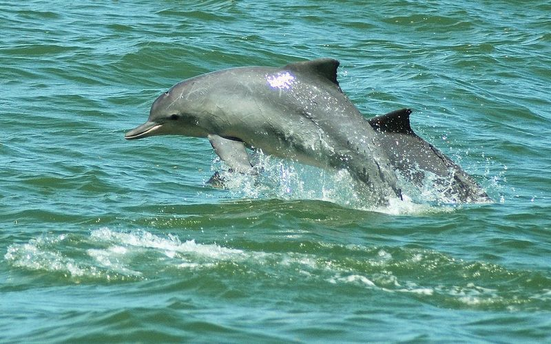

Boto-Cinza

# Repositório de dados de ocorrência: **Global Biodiversity Information Facility (GBIT)**

### Adicionando os pacotes exigidos para a atividade

```r
library(tidyverse)
# install.packages("devtools")
devtools::install_github("r-lib/conflicted")
library(rgbif)
library(dplyr)
library(bdc)
library(CoordinateCleaner)
library(ggmap)
```

```r
library(maps)
citation("ggmap")
```

```
##
##   D. Kahle and H. Wickham. ggmap: Spatial Visualization with ggplot2.
##   The R Journal, 5(1), 144-161. URL
##   http://journal.r-project.org/archive/2013-1/kahle-wickham.pdf
##
## A BibTeX entry for LaTeX users is
##
##   @Article{,
##     author = {David Kahle and Hadley Wickham},
##     title = {ggmap: Spatial Visualization with ggplot2},
##     journal = {The R Journal},
##     year = {2013},
##     volume = {5},
##     number = {1},
##     pages = {144--161},
##     url = {https://journal.r-project.org/archive/2013-1/kahle-wickham.pdf},
##   }
```

```r
library(mapdata)
library(plotly)
```

## Dados de ocorrênica do Boto-Cinza *Sotalia guianensis*

```r
# checar funcoes
?occ_data
```

```
## starting httpd help server ... done
```

```r
boto_gbif <- occ_data(scientificName = "Sotalia guianensis",
                      hasCoordinate = TRUE,
                      hasGeospatialIssue=FALSE)
# dimensoes
dim(boto_gbif)
```

```r
dim(boto_gbif$data)
```

```
## [1] 500 107
```

```r
# checar campos
boto_gbif$data %>% names
```

```
##   [1] "key"                              "scientificName"
##   [3] "decimalLatitude"                  "decimalLongitude"
##   [5] "issues"                           "datasetKey"
##   [7] "publishingOrgKey"                 "installationKey"
##   [9] "publishingCountry"                "protocol"
##  [11] "lastCrawled"                      "lastParsed"
##  [13] "crawlId"                          "hostingOrganizationKey"
##  [15] "basisOfRecord"                    "occurrenceStatus"
##  [17] "taxonKey"                         "kingdomKey"
##  [19] "phylumKey"                        "classKey"
##  [21] "orderKey"                         "familyKey"
##  [23] "genusKey"                         "speciesKey"
##  [25] "acceptedTaxonKey"                 "acceptedScientificName"
##  [27] "kingdom"                          "phylum"
##  [29] "order"                            "family"
```

[output cut: 39 more lines]

## Avaliação dos problemas relatados para o conjunto de dados com a função **gbif_issues**.

```r
# checar problemas reportados
issues_gbif <- boto_gbif$data$issues %>%
  unique() %>%
  strsplit(., "[,]") %>%
  unlist()

gbif_issues() %>%
  data.frame() %>%
  filter(code %in% issues_gbif)
```

```
##       code                                            issue
## 1      cdc               CONTINENT_DERIVED_FROM_COORDINATES
## 2  cdround                               COORDINATE_ROUNDED
## 3     cudc                 COUNTRY_DERIVED_FROM_COORDINATES
## 4      cum                                 COUNTRY_MISMATCH
## 5   gass84                     GEODETIC_DATUM_ASSUMED_WGS84
## 6   gdativ                           GEODETIC_DATUM_INVALID
## 7 muluriiv                           MULTIMEDIA_URI_INVALID
## 8    osiic OCCURRENCE_STATUS_INFERRED_FROM_INDIVIDUAL_COUNT
##                                                                                                                                description
## 1                                              The interpreted continent is based on the coordinates, not the verbatim string information.
## 2                                                                                  Original coordinate modified by rounding to 5 decimals.
## 3                                                The interpreted country is based on the coordinates, not the verbatim string information.
## 4                                                           Interpreted country for dwc:country and dwc:countryCode contradict each other.
## 5 Indicating that the interpreted coordinates assume they are based on WGS84 datum as the datum was either not indicated or interpretable.
## 6                                                                                       The geodetic datum given could not be interpreted.
## 7                                                                                         An invalid uri is given for a multimedia object.
## 8                                                                           Occurrence status was inferred from the individual count value
##         type
## 1 occurrence
## 2 occurrence
## 3 occurrence
## 4 occurrence
## 5 occurrence
## 6 occurrence
## 7 occurrence
## 8 occurrence
```

## Visualizando as dimensões e campos do arquivo

```r
# verificando as dimensões do arquivo
dim(boto_gbif)
```

```r
# Detalhando os campos do arquivo
dim(boto_gbif$data)
```

```
## [1] 500 107
```

```r
boto_gbif$data %>% names
```

```
##   [1] "key"                              "scientificName"
##   [3] "decimalLatitude"                  "decimalLongitude"
##   [5] "issues"                           "datasetKey"
##   [7] "publishingOrgKey"                 "installationKey"
##   [9] "publishingCountry"                "protocol"
##  [11] "lastCrawled"                      "lastParsed"
##  [13] "crawlId"                          "hostingOrganizationKey"
##  [15] "basisOfRecord"                    "occurrenceStatus"
##  [17] "taxonKey"                         "kingdomKey"
##  [19] "phylumKey"                        "classKey"
##  [21] "orderKey"                         "familyKey"
##  [23] "genusKey"                         "speciesKey"
##  [25] "acceptedTaxonKey"                 "acceptedScientificName"
##  [27] "kingdom"                          "phylum"
##  [29] "order"                            "family"
```

[output cut: 39 more lines]

## Filtro de dados

### Algumas informações serão filtradas para analisar os dados

```r
boto_gbif1 <- boto_gbif$data %>%
  dplyr::select(scientificName, acceptedScientificName, decimalLatitude, decimalLongitude,
         issues, basisOfRecord, occurrenceStatus, rightsHolder,
         datasetName, recordedBy, locality,habitat,stateProvince)
```

## Validação de dados

### Para a espécie escolhida não há dados disponíveis de profundidade porque o animal não vive em águas profundas, apenas em áreas de até 50 metros de profundidade.

```r
boto_gbif1 <- boto_gbif$data %>%
  dplyr::select(scientificName, acceptedScientificName, decimalLatitude, decimalLongitude,
         issues, waterBody, basisOfRecord, occurrenceStatus, rightsHolder,
         datasetName, recordedBy, locality, habitat)
```

### Temos 500 ocorrências com 13 variáveis. Aplicaremos a função **distinc** filtrando somente as variáveis que são únicas.

```r
boto_gbif1 <- boto_gbif1 %>%
  distinct()
```

### Após a função, ficamos com 443 dados de ocorrência. Para identificar todos os valores únicos presentes nos dados, vamos aplicar a função **unique** a cada coluna com um loop na função **lapply**.

```r
# checar niveis dos fatores
lapply(boto_gbif1, unique)
```

```
## $scientificName
## [1] "Sotalia guianensis (P.-J.van Bénéden, 1864)"
## [2] "Sotalia fluviatilis guianensis (P.-J.van Bénéden, 1864)"
##
## $acceptedScientificName
## [1] "Sotalia guianensis (P.-J.van Bénéden, 1864)"
##
## $decimalLatitude
##   [1] -20.635858 -20.229676   5.852159 -20.204314   5.841834 -24.888458
##   [7] -22.819751 -22.999603 -20.686140 -25.113131 -20.316822 -25.034690
##  [13] -20.377979 -20.339716  10.550476   5.906503  -6.895379 -17.925516
##  [19] -25.097495  -8.312442  -8.222975   5.971873   5.831553 -26.382902
##  [25] -24.835487 -25.464325 -24.612249 -23.734100 -23.917683 -23.908083
##  [31] -25.103078 -25.038284 -25.100625 -25.054059 -25.125465 -25.076768
##  [37] -25.093177 -25.073202 -25.102813 -25.082385 -25.017262 -25.064299
```

[output cut: 336 more lines]

# Validação de dados

### Agora iniciaremos uma avaliação mais minuciosa dos dados, como a validação das coordenadas geográficas usando as funções dos pacotes **CoordinateCleaner** e **bcd**.

```r
library(bdc)
library(CoordinateCleaner)

# checar coordenadas válidas
check_pf <-
  bdc::bdc_coordinates_outOfRange(
    data = boto_gbif1,
    lat = "decimalLatitude",
    lon = "decimalLongitude")
```

```
##
## bdc_coordinates_outOfRange:
## Flagged 0 records.
## One column was added to the database.
```

```r
# checar coordenadas válidas e próximas a capitais (muitas vezes as coordenadas são erroneamente associadas a capitais dos países)

cl <- boto_gbif1 %>%
  select(acceptedScientificName, decimalLatitude, decimalLongitude) %>%
  rename(decimallongitude = decimalLongitude,
         decimallatitude = decimalLatitude,
         scientificName = acceptedScientificName) %>%
  as_tibble() %>%
  mutate(val = cc_val(., value = "flagged"),
         sea = cc_sea(., value = "flagged"),
         capital = cc_cap(., value = "flagged"))
```

```
## Testing coordinate validity
```

```
## Flagged 0 records.
```

```
## Testing sea coordinates
```

```
## Flagged 148 records.
```

```
## Testing country capitals
```

```
## Flagged 44 records.
```

[figure not shown]

```r
# verificar coordenadas com flags

# capitais (padrão é um raio de 10km)
cl %>%
  rename(decimalLongitude = decimallongitude,
         decimalLatitude = decimallatitude) %>%
  bdc::bdc_quickmap(., col_to_map = "capital")
```

### As funções indicam alguns alertas. Na imagem abaixo podemos dar uma rápida conferida nos alertas indicados pelas funções. O boto-cinza habita estritamente em regiões costeiras por isso algumas ocorrências estão muito próximas a capitais.

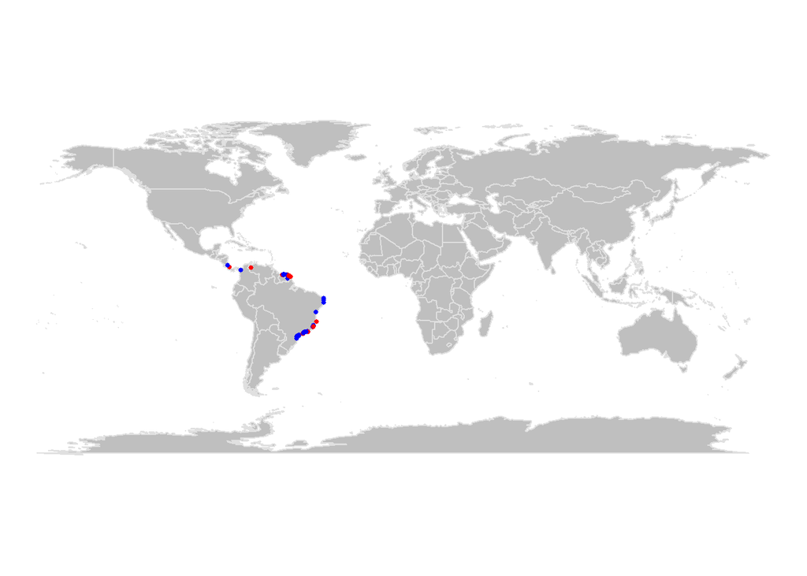

```r
cl %>%
  rename(decimalLongitude = decimallongitude,
         decimalLatitude = decimallatitude) %>%
  bdc::bdc_quickmap(., col_to_map = "sea")
```

```r
# investigar niveis suspeitos
boto_gbif1 %>%
  distinct(waterBody) %>%
  pull()
```

```
## [1] NA                     "South Atlantic Ocean" "Suriname"
## [4] "Global"               "Global,French EEZ"
```

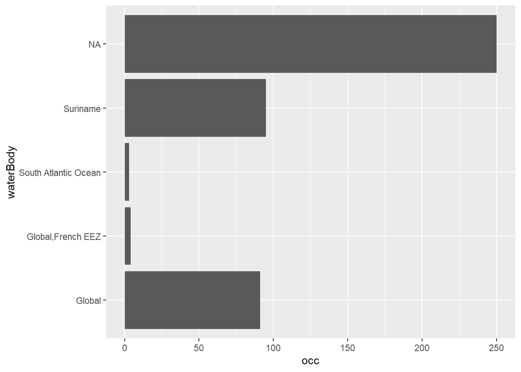

```r
# waterBody
boto_gbif1 %>%
  group_by(waterBody) %>%
  summarise(occ = length(scientificName)) %>%
  ggplot(aes(occ, y=waterBody)) +
    geom_bar(stat = 'identity')
```

# Mapa interativo com dados do gênero *Sotalia sp.*

```r
library(tidyverse)
library(rgbif)

# ocorrencias
boto_gbif <- occ_data(scientificName = "Sotalia",
                      hasCoordinate = TRUE,
                      hasGeospatialIssue = FALSE)
# checar issues
issues_gbif <- boto_gbif$data$issues %>%
  unique() %>%
  strsplit(., "[,]") %>%
  unlist()

gbif_issues() %>%
  data.frame() %>%
  filter(code %in% issues_gbif)
```

```
##        code                                            issue
## 1       cdc               CONTINENT_DERIVED_FROM_COORDINATES
## 2   cdround                               COORDINATE_ROUNDED
## 3      cudc                 COUNTRY_DERIVED_FROM_COORDINATES
## 4       cum                                 COUNTRY_MISMATCH
## 5    gass84                     GEODETIC_DATUM_ASSUMED_WGS84
## 6    gdativ                           GEODETIC_DATUM_INVALID
## 7 preneglat                        PRESUMED_NEGATED_LATITUDE
## 8     cdumi            COORDINATE_UNCERTAINTY_METERS_INVALID
## 9     osiic OCCURRENCE_STATUS_INFERRED_FROM_INDIVIDUAL_COUNT
##                                                                                                                                description
## 1                                              The interpreted continent is based on the coordinates, not the verbatim string information.
## 2                                                                                  Original coordinate modified by rounding to 5 decimals.
## 3                                                The interpreted country is based on the coordinates, not the verbatim string information.
## 4                                                           Interpreted country for dwc:country and dwc:countryCode contradict each other.
## 5 Indicating that the interpreted coordinates assume they are based on WGS84 datum as the datum was either not indicated or interpretable.
## 6                                                                                       The geodetic datum given could not be interpreted.
## 7                                                                               Latitude appears to be negated, e.g. 32.3 instead of -32.3
## 8                                                                           Indicates an invalid or very unlikely dwc:uncertaintyInMeters.
## 9                                                                           Occurrence status was inferred from the individual count value
##         type
## 1 occurrence
## 2 occurrence
## 3 occurrence
## 4 occurrence
## 5 occurrence
## 6 occurrence
## 7 occurrence
## 8 occurrence
## 9 occurrence
```

### Os dados de ocorrência do gênero escolhido foi carregado e agora o mapa interativo será criado.

```r
# selecionar variaveis
boto <- boto_gbif$data %>%
  dplyr::select(scientificName, decimalLatitude, decimalLongitude) %>%
  distinct()
```

```r
library(leaflet)

# conferir no mapa
boto %>%
  leaflet() %>%
  addTiles() %>%
  addMarkers(~decimalLongitude,
             ~decimalLatitude)
```

[interactive chart not shown]

### Para o gênero *Sotalia sp.* foram encontrados registros para duas espécies e uma subespécie.

```r
pal <- colorFactor(palette = "viridis", domain = unique(boto$scientificName))

boto %>%
  leaflet() %>%
  addTiles() %>%
  addCircleMarkers(~decimalLongitude,
                   ~decimalLatitude,
                   radius = 5,
                   label = ~as.character(scientificName),
                   color = ~pal(boto$scientificName),
                   stroke = FALSE, fillOpacity = 0.5) %>%
  addLegend('bottomright',
            colors = unique(pal(boto$scientificName)),
            labels = unique(boto$scientificName),
            title = 'Espécie',
            opacity = 0.5)
```

[interactive chart not shown]